# JUDGE channel — IV. Internal structure & validity evidence

Dimensionality, structural invariance across raters, and what it does (and doesn’t) license

ecb

2026-07-22

## Frame, and a caution held throughout

In the Messick / *Standards* sense, **internal-structure evidence** asks whether the relationships among the parts of a measure conform to the construct it claims. For the JUDGE similarity that is two questions:

1. **Dimensionality & pattern** — does the symmetrized similarity organize into interpretable trait dimensions?
2. **Structural invariance** — do the 9 raters *agree* on that structure (is it a property of the measurement, not of one model)?

I keep one caution front and center (ecb’s steer): **recovering an interpretable — even Big-Five-shaped — structure is consistent with measuring personality description, but is not by itself proof of validity.** A live alternative is that the model encodes the *lexical/evaluative co-occurrence of trait words* (the “concept of personality,” not a personality; rgb’s `representation_not_intention`). Internal structure can establish that the instrument is *coherent and reproducible*; it cannot, alone, adjudicate what the coherent thing *is*. Criterion evidence against humans is a separate — and, per ecb, inferentially weaker — strand, deferred to a follow-up.

The measurement object is the **cohort-consensus** symmetrized similarity (Report III: the dependable unit), built over the 8 discriminating raters (the one range-restricted rater, `Llama3.2-3B`, adds little *differentiated* structure and, since it agrees with the crowd, including it shifts the consensus negligibly — Report V), transformed by profile-correlation — the same second-order transform rgb used, chosen because the human reference matrix is itself a profile correlation over people (kept consistent so any later comparison is apples-to-apples).

```r
sym <- fread_gz("sym_ev.csv.gz")
disc <- setdiff(MODELS, "Llama")            # drop the one flat rater (FalconMamba pending)
Sbar <- Reduce(`+`, lapply(disc, function(m) build_matrix(sym, m, "sym"))) / length(disc)
Rcons <- profile_cor(Sbar)
pca_load <- function(R, k){
  e <- eigen(R, symmetric = TRUE)
  L <- e$vectors[,1:k,drop=FALSE] %*% diag(sqrt(pmax(e$values[1:k],0)), k)
  stats::varimax(L)$loadings[]
}
```

## 1. Dimensionality: one dominant evaluative factor, then a trait ladder

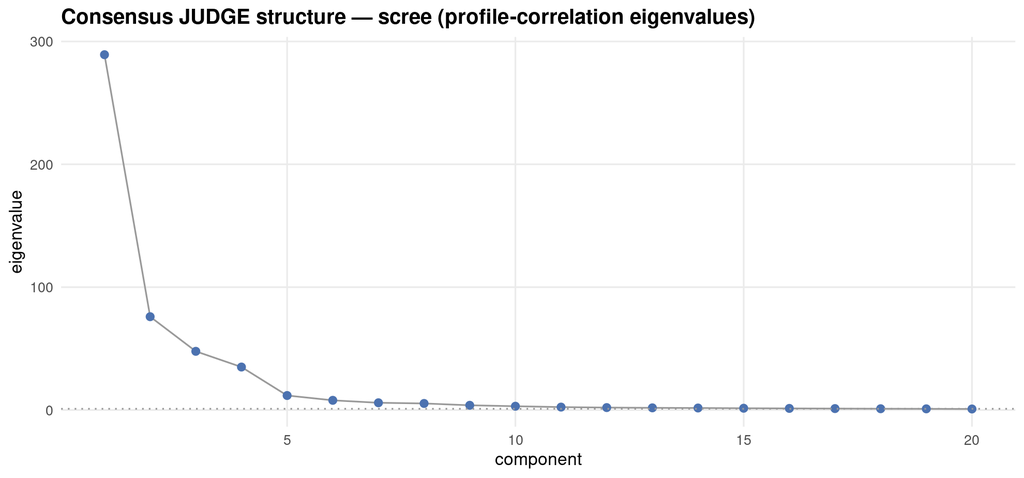

```r
ev <- eigen(Rcons, symmetric = TRUE, only.values = TRUE)$values
scr <- tibble(k = 1:20, eigen = ev[1:20])
ggplot(scr, aes(k, eigen)) + geom_line(colour="grey60") + geom_point(size=2, colour="#4C72B0") +
  geom_hline(yintercept = 1, linetype = 3, colour = "grey60") +
  scale_x_continuous(breaks = seq(0,20,5)) +
  labs(title = "Consensus JUDGE structure — scree (profile-correlation eigenvalues)",
       x = "component", y = "eigenvalue") + theme_judge()
```

```r
cat(sprintf("PC1 explains %.0f%% of common variance; PC1/PC2 = %.2f. A single strong general factor.\n",
    100*ev[1]/sum(pmax(ev,0)), ev[1]/ev[2]))
```

```
## PC1 explains 55% of common variance; PC1/PC2 = 3.81. A single strong general factor.
```

## 2. The five-factor solution resembles the Big Five (read carefully)

```r
Lc <- pca_load(Rcons, 5)
top_adj <- function(f, n = 10){
  o <- order(-abs(Lc[,f]))[1:n]
  paste0(ADJ[o], " (", sprintf("%+.2f", Lc[o,f]), ")", collapse = ", ")
}
labs <- c("Competence / evaluation (halo)", "Antagonism  (low Agreeableness)",
          "Negative affect  (Neuroticism)", "Playful–uninhibited  (low Conscientiousness / Extraversion)",
          "Traditional–predictable  (low Openness)")
tibble(Factor = paste0("F", 1:5), `Tentative label` = labs,
       `Top-loading adjectives` = sapply(1:5, top_adj, n = 7)) %>%
  knitr::kable(caption = "Varimax(5) of the consensus JUDGE similarity. Labels are interpretive.")
```

Varimax(5) of the consensus JUDGE similarity. Labels are interpretive.

| Factor | Tentative label | Top-loading adjectives |
| --- | --- | --- |
| F1 | Competence / evaluation (halo) | outstanding (-0.95), exceptional (-0.95), impressive (-0.95), skilled (-0.94), talented (-0.94), bright (-0.94), remarkable (-0.94) |
| F2 | Antagonism (low Agreeableness) | bossy (-0.95), egotistical (-0.95), arrogant (-0.94), argumentative (-0.94), demanding (-0.94), aggressive (-0.94), conceited (-0.93) |
| F3 | Negative affect (Neuroticism) | unsure (+0.91), afraid (+0.89), scared (+0.89), sad (+0.88), worried (+0.88), anxious (+0.88), embarrassed (+0.88) |
| F4 | Playful–uninhibited (low Conscientiousness / Extraversion) | informal (+0.80), carefree (+0.73), casual (+0.71), talkative (+0.69), naive (+0.69), uninhibited (+0.68), spontaneous (+0.66) |
| F5 | Traditional–predictable (low Openness) | predictable (-0.84), traditional (-0.69), conservative (-0.67), uncreative (-0.66), boring (-0.64), old-fashioned (-0.62), average (-0.60) |

Four of the five differentiated factors map recognizably onto **Agreeableness (reversed: antagonism), Neuroticism, Openness (reversed), and a Conscientiousness/Extraversion blend**, alongside the dominant **evaluative-competence** factor. This is *internal* structure — extracted from the models’ own judgments, with no human key imposed — so its Big-Five resemblance is meaningful evidence that the JUDGE instrument organizes trait words along personality-like lines.

**But note the two hedges the caution demands.** (a) The first and largest factor is evaluative, not a clean Big-Five trait — an *implicit-personality-theory* halo, which is exactly what a lexical-co-occurrence account also predicts. (b) The C and E poles are blended rather than cleanly separated. So “resembles the Big Five” is honest; “recovers the Big Five” would overclaim.

## 3. Structural invariance: the raters agree on the structure

The stronger internal-structure evidence is **agreement across raters** — if each model independently yields the same factor pattern, the structure is a property of the measurement, not an artefact of one model. Aligning each rater’s varimax(5) solution to the consensus (greedy factor matching, sign-corrected) and taking Tucker’s congruence:

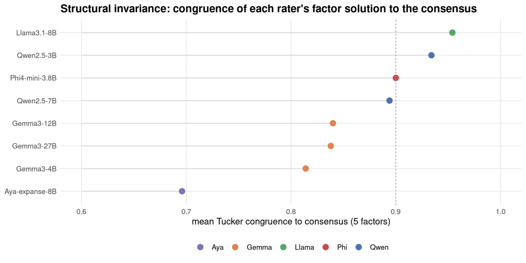

```r
align_cong <- function(Lm, Lc){
  C <- abs(psych::factor.congruence(Lm, Lc))     # 5x5 |congruence|
  best <- numeric(ncol(Lc)); used <- c()
  ord <- order(-apply(C,2,max))
  for(f in ord){ cand <- setdiff(order(-C[,f]), used); pick <- cand[1]; best[f] <- C[pick,f]; used <- c(used,pick) }
  best
}
congmat <- sapply(disc, function(m){
  Lm <- pca_load(profile_cor(build_matrix(sym, m, "sym")), 5)
  align_cong(Lm, Lc)
})
rownames(congmat) <- paste0("F",1:5)
per_model <- colMeans(congmat)
inv <- tibble(model = disc, display = DISPLAY[disc], family = FAMILY[disc],
              mean_cong = per_model) %>% arrange(desc(mean_cong)) %>%
  mutate(display = factor(display, levels = rev(display)))
ggplot(inv, aes(mean_cong, display, colour = family)) +
  geom_segment(aes(x=0.6, xend=mean_cong, yend=display), colour="grey85") +
  geom_point(size=3) + scale_colour_manual(values = FAM_PAL, name = NULL) +
  geom_vline(xintercept = 0.9, linetype = 3, colour="grey55") +
  labs(title="Structural invariance: congruence of each rater's factor solution to the consensus",
       x="mean Tucker congruence to consensus (5 factors)", y=NULL) +
  xlim(0.6, 1) + theme_judge()
```

```r
cat(sprintf("Mean congruence to consensus across raters: %.2f (Tucker ≥0.85 conventionally 'fair', ≥0.95 'identical').\n",
    mean(per_model)))
```

```
## Mean congruence to consensus across raters: 0.86 (Tucker ≥0.85 conventionally 'fair', ≥0.95 'identical').
```

```r
tibble(Factor = paste0("F",1:5), Label = labs,
       `Mean congruence` = round(rowMeans(congmat),2),
       `Min across raters` = round(apply(congmat,1,min),2)) %>%
  knitr::kable(caption="Which factors replicate across raters. The evaluative/antagonism/affect factors are the most invariant.")
```

Which factors replicate across raters. The evaluative/antagonism/affect factors are the most invariant.

| Factor | Label | Mean congruence | Min across raters |
| --- | --- | --- | --- |
| F1 | Competence / evaluation (halo) | 0.94 | 0.84 |
| F2 | Antagonism (low Agreeableness) | 0.96 | 0.92 |
| F3 | Negative affect (Neuroticism) | 0.90 | 0.48 |
| F4 | Playful–uninhibited (low Conscientiousness / Extraversion) | 0.81 | 0.69 |
| F5 | Traditional–predictable (low Openness) | 0.69 | 0.17 |

The evaluative, antagonism and negative-affect factors are the most reproducible; the low-Openness factor is the least invariant — the same weak-Openness signal rgb found in the *representation*, here at the structural-reliability level.

## 4. The general factor as a discriminant-validity threat

How much of the apparent structure is *just* the evaluative halo? Partialling the first (general) component out of the consensus and re-extracting shows what differentiated trait structure survives:

```r
e <- eigen(Rcons, symmetric=TRUE)
Rres <- Rcons - e$values[1]*tcrossprod(e$vectors[,1])   # remove PC1
evr <- eigen(Rres, symmetric=TRUE, only.values=TRUE)$values
Lres <- pca_load(Rres, 4)
congres <- sapply(disc, function(m){
  Rm <- profile_cor(build_matrix(sym, m, "sym"))
  em <- eigen(Rm, symmetric=TRUE); Rmr <- Rm - em$values[1]*tcrossprod(em$vectors[,1])
  mean(align_cong(pca_load(Rmr,4), Lres))
})
cat(sprintf("After removing the general factor: 4 residual factors still replicate across raters at mean congruence %.2f.\n", mean(congres)))
```

```
## After removing the general factor: 4 residual factors still replicate across raters at mean congruence 0.87.
```

```r
cat(sprintf("Residual top eigenvalues: %s\n", paste(round(head(evr,5),1), collapse=", ")))
```

```
## Residual top eigenvalues: 76, 47.8, 35, 11.8, 7.9
```

Reassuringly, differentiated trait structure **survives** removing the general factor and **still replicates across raters** — so the instrument is not *only* an evaluative halo; there is reproducible discriminant structure beneath it. But the halo’s dominance (55% of common variance) is a real limit on discriminant validity: for any downstream use, trait-specific JUDGE scores should be taken **net of the general evaluative factor**, or much of what looks like (say) an Agreeableness signal will be halo.

## 5. Response-process evidence (recap)

Internal structure is buttressed by the **response-process** evidence from Report I: for the discriminating raters the per-judgment entropy traces a sensible inverted-U in similarity (certain at the poles, graded in the middle), and Report III showed between-rater disagreement co-locates with within-rater uncertainty. The judgments behave like a graded construct measurement, not like noise or a degenerate heuristic — a necessary (not sufficient) condition for the structural evidence to mean anything.

## What this establishes — and what it doesn’t

**Established (internal-structure + structural-invariance evidence):**

- The consensus JUDGE similarity is **coherent and low-rank** — one dominant evaluative factor plus a small ladder of differentiated trait factors.
- That structure is **reproducible across raters** (mean congruence 0.86; 0.87 again on the general-factor-removed residual) — it is a property of the *measurement*, not one model. This is real structural reliability, and the strongest validity-relevant claim the internal evidence supports.
- The differentiated factors **resemble** Agreeableness, Neuroticism, Openness and a C/E blend.

**Not established (and not claimable from this evidence):**

- That the models “have” personalities, or that the structure reflects anything beyond **learned lexical/evaluative co-occurrence of trait descriptors** — the general evaluative factor is equally predicted by that deflationary account.
- That the structure matches *human* personality structure. That is criterion evidence, handled separately and — per ecb — with care: **a match to humans would be consistent with validity but is not itself validity**, and a mismatch would not by itself disconfirm a coherent, reliable measurement of the models’ own implicit personality theory.